# 2nd Preliminary analysis for 2019-nCoV cases reported in some Asian countries and regions

Qingyuan Zhao

2/2/2020

The 2nd preliminary analysis uses almost the same dataset as the [first preliminary analysis](https://htmlpreview.github.io/?https://github.com/qingyuanzhao/2019-nCov-Data/blob/master/Feb1.html) but attempts to use a simple model to acknowledge that this dataset contains only “shadows” of the real epidemic in Wuhan. Another important distinction is that we will directly model the infection time that can be imputed by the symptom onset time and the incubation interval reported in [this NEJM article](https://www.nejm.org/doi/full/10.1056/NEJMoa2001316).

# Data preprocessing

We first read and pre-process the data. This is very similar to the [first preliminary analysis](https://htmlpreview.github.io/?https://github.com/qingyuanzhao/2019-nCov-Data/blob/master/Feb1.html). The only difference is that we now start our date indexing from the December 1st instead of January 1st (because some infections happened in December).

```r
source("functions.R")

data <- read.table("Feb2.tsv", sep = "\t", header = TRUE)

data$Confirmed <- date.process(data$Confirmed)
data$Arrived <- date.process(data$Arrived)
data$Symptom <- date.process(data$Symptom)
data$Initial <- date.process(data$Initial)
data$Hospital <- date.process(data$Hospital)

## Only focus on the following countries/regions: Japan, Singapore, Taiwan, HongKong, Macau, Korea
data$Country_or_Region <- do.call(rbind, strsplit(as.character(data$Case), "-"))[, 1]
data <- subset(data, Country_or_Region %in% c("Japan", "Singapore", "Taiwan", "Korea", "Hong Kong", "Macau"))
table(data$Country_or_Region)
```

```
##
##     Japan     Korea     Macau Singapore    Taiwan
##        15        12         7        18        10
```

```r
## Only consider cases who were (most certainly) infected in Wuhan and arrived on or before 23th of January
data <- subset(data, Outside != "Y" & Arrived <= 23+31)
nrow(data)
```

```
## [1] 43
```

# Imputation of infection time

```r
data <- parse.infected(data)
subset(data, Case == "Japan-12")
```

[output not shown]

To illustrate the imputation of infection time, we first impute the few missing symptom onset dates using the *simple.impute.onset* function (described in the [first preliminary analysis](https://htmlpreview.github.io/?https://github.com/qingyuanzhao/2019-nCov-Data/blob/master/Feb1.html)).

```r
## Simple imputation of symptom onset
set.seed(20200202)
symptom.imputed <- simple.impute.onset(data)
```

```
## [1] "6 of 43 symptom onset date(s) are missing."
## [1] "Imputing by initial medical visit date minus 2 days..."
## [1] "2 of 43 symptom onset date(s) are still missing."
## [1] "Imputing by confirmation date minus 4 days..."
## [1] "0 sympton onset date(s) are missing after imputation."
```

The infection date is imputed by the symptom onset date minus a random draw from the distribution of the incubation period, truncated to the infection interval. This is implemented in the *impute.infected* function. Notice that [the NEJM article](https://www.nejm.org/doi/full/10.1056/NEJMoa2001316) only reported the estimated mean (5.2 days) and 95% quantile (12.5 days) of the incubation period. I matched them with a gamma distribution, although the histogram is slightly different from Figure 2A in that article.

```r
infected.imputed <- impute.infected(symptom.imputed, data$Infected_first, data$Infected_last,
                                    incubation_alpha = 1.92, incubation_beta = 0.37)
```

# Modeling the “shadows”" of an epidemic

Next we describe a model that takes into account that we are only observing “shadows” of the epidemic in Wuhan.

- Let $WP_t$ be the population of Wuhan at the end of day $t$ (because of the Lunar New Year, this number was dropping significantly before January 23). This will be estimated later. We will assume $W_t$ is a constant before January 1 as migration data on https://qianxi.baidu.com/ is only available for January 2020.
- Let $WI_t$ be the number of new infections in Wuhan on day $t$, among which $WI_{t,s}$ remained in Wuhan at the end of day $s$. We assume the following dynamics:
  $$WI_{t,s} = WI_t \cdot \frac{WP_{s}}{WP_{t-1}}.$$
- Let $WT_t$ be the total number of infections remain in Wuhan at the end of day $t$, which is given by
  $$WT_t = \sum_{s = 1}^{t} WI_{s,t} = \sum_{s=1}^t WI_s \cdot \frac{WP_t}{WP_{s-1}}.$$
- We assume the new infection $WI_t$ is a fraction of the total infection in the previous day.
  $$WI_{t} = e^{r} \cdot WT_{t-1}.$$
- Let $AP_t$ people travelled to our selected Asian countries/regions on day $t$. Because most people travel to these countries/regions via air, we assume it is a constant $AP_t = AP$ and will estimate it later.
- Let $AI_t$ be the number of new infections in Wuhan on day $t$ who travelled to our selected Asian countries/regions before January 23. We assume it has the distribution
  $$AI_t \sim \text{Poisson} \Big\{ WI_t \cdot \frac{\sum_{s=t}^N AP_s}{WP_{t-1}} \Big\}.$$

```r
library(rstan)
options(mc.cores = parallel::detectCores())
rstan_options(auto_write = TRUE)

stan_code <- "
data {
  int<lower=0> N;
  int<lower=0> AI[N];
  vector[N] WP;
  real WI_Dec1_prior_mean;
  real WI_Dec1_prior_sd;
  real OP_prior_mean;
  real r_prior_mean;’
}
parameters {
  real<lower=0> r;
  real<lower=0> WI_Dec1;
  real<lower=0> OP;
}
transformed parameters {
  vector[N] WI;
  vector[N] WT;
  vector[N] AI_mean;
  WI[1] = WI_Dec1;
  WT[1] = WI_Dec1;
  for (t in 2:N) {
    WI[t] = WT[t-1] * exp(r);
    WT[t] = WP[t] * (WI[1] / WP[1] + sum(WI[2:t] / WP[1:(t-1)]))
    AI_mean[t] = WI[t] * (1 - WP[N] / WP[t])
  }
}
model {
  r ~ exponential(1 / r_prior_mean);
  WI_Dec1 ~ gamma(WI_Dec1_prior_mean^2 / WI_Dec1_prior_sd^2,
                  WI_Dec1_prior_mean / WI_Dec1_prior_sd^2);
  OP ~ exponential(1 / OP_prior_mean);
  AI ~ poisson(AI_mean);
}
generated quantities {
  vector[N] WI_total;
  WI_total = cumulative_sum(WI);
}
"

## sm <- stan_model(model_code = stan_code)
```

# Prior parameters

```r
N <- 31 + 23 ## Total number of days
stan_data <- list(N = N)
```

We obtained migration data from https://qianxi.baidu.com and this [web article](https://www.jiqizhixin.com/articles/2020-01-27-2). They are currently saved in *wuhan_travel_data.R*. According to the mayor of Wuhan, 5 million people left Wuhan before the Lunar New Year and 9 million remain in the city as of 26th of January. We use this information to estimate the population of Wuhan in January.

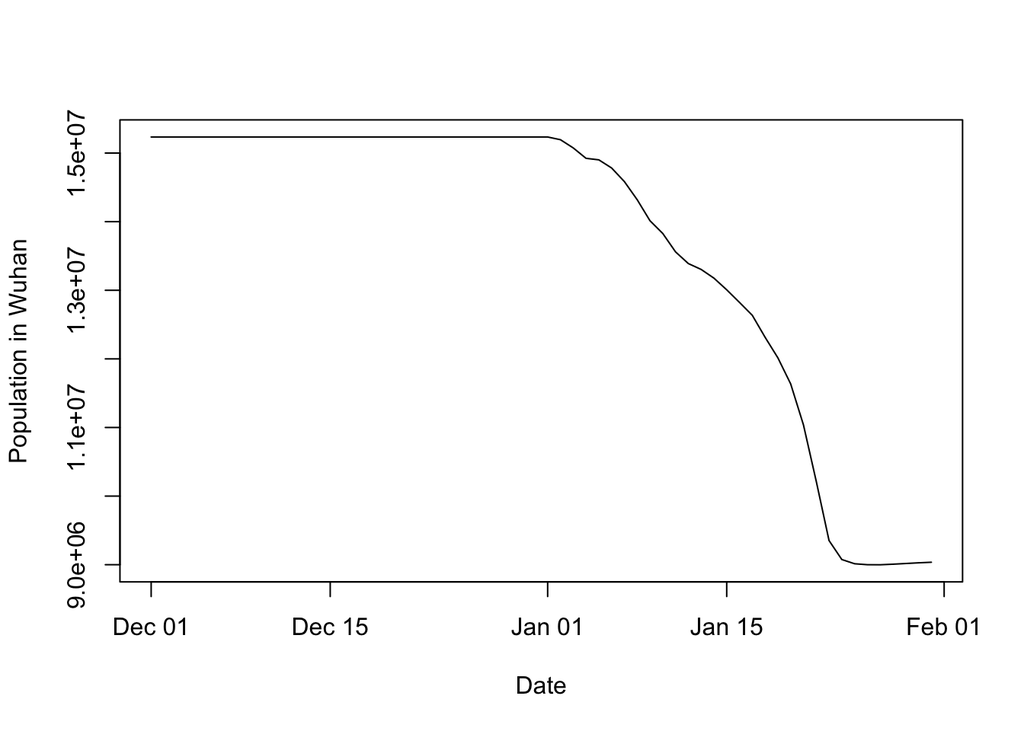

```r
source("wuhan_travel_data.R")

net_leave_rate <- wuhan_travel$leave_rate - wuhan_travel$arrive_rate
qianxi_unit <- - (wuhan_population_Jan26 - wuhan_population_Jan10) / sum(net_leave_rate[10:25])
WP <- rep(0, 31 + 31)
WP[31 + 1:31] <- - cumsum(net_leave_rate) * qianxi_unit # January
WP[1:31] <- WP[1 + 31] # assume December is equal to January 1st
WP <- WP + wuhan_population_Jan26 - WP[31 + 26] # center the series
plot(1:(31+31) - 1 + as.Date("2019-12-01"), WP, type = "l",
     xlab = "Date", ylab = "Population in Wuhan")
```

```r
stan_data$WP <- WP[1:N]
```

We estimate the travel to the selected Asian countries/regions using air traffic planning data from this [web article](https://www.jiqizhixin.com/articles/2020-01-27-2). We assume twice as many people entered Hong Kong and Macau via train/car than air. We assume 80% of the planned aircraft seats were taken.

```r
(stan_data$OP_prior_mean <-
   (taiwan_air + japan_air + singapore_air + korea_air + hongkong_air*3 + macau_air*3) / 24 * 0.8)
```

```
## [1] 2743.4
```

```r
stan_data$WI_Dec1_prior_mean = 0.5
stan_data$WI_Dec1_prior_sd = 5
stan_data$r_prior_mean = log(2) / 7 ## doubling every 7 days
```

# Bayesian fit for one imputation

We add the imputed infection dates to the model.

```r
as.count <- function(infected, last_date = 31 + 23) {
    table(factor(infected, levels = 1:last_date))
}
stan_data$AI <- as.count(infected.imputed, N)
```

We then sample from the posterior distribution in this model:

```r
## fit <- sampling(sm, data  = stan_data, init = 3, iter = 4000)
```